# Draft EDA Airline Satisfaction

2025-03-04

## Exploratory Data Analysis

Importing Library

```r
library(dplyr)
```

```r
library(ggplot2)
library(skimr)
library(DataExplorer)
```

Read Data

```r
data <- read.csv("airline_passenger_satisfaction.csv")
str(data)
```

```
## 'data.frame':    129880 obs. of  24 variables:
##  $ ID                                    : int  1 2 3 4 5 6 7 8 9 10 ...
##  $ Gender                                : chr  "Male" "Female" "Male" "Male" ...
##  $ Age                                   : int  48 35 41 50 49 43 43 60 50 38 ...
##  $ Customer.Type                         : chr  "First-time" "Returning" "Returning" "Returning" ...
##  $ Type.of.Travel                        : chr  "Business" "Business" "Business" "Business" ...
##  $ Class                                 : chr  "Business" "Business" "Business" "Business" ...
##  $ Flight.Distance                       : int  821 821 853 1905 3470 3788 1963 853 2607 2822 ...
##  $ Departure.Delay                       : int  2 26 0 0 0 0 0 0 0 13 ...
##  $ Arrival.Delay                         : int  5 39 0 0 1 0 0 3 0 0 ...
##  $ Departure.and.Arrival.Time.Convenience: int  3 2 4 2 3 4 3 3 1 2 ...
##  $ Ease.of.Online.Booking                : int  3 2 4 2 3 4 3 4 1 5 ...
##  $ Check.in.Service                      : int  4 3 4 3 3 3 4 3 3 3 ...
##  $ Online.Boarding                       : int  3 5 5 4 5 5 4 4 2 5 ...
##  $ Gate.Location                         : int  3 2 4 2 3 4 3 4 1 2 ...
##  $ On.board.Service                      : int  3 5 3 5 3 4 5 3 4 5 ...
##  $ Seat.Comfort                          : int  5 4 5 5 4 4 5 4 3 4 ...
##  $ Leg.Room.Service                      : int  2 5 3 5 4 4 5 4 4 5 ...
##  $ Cleanliness                           : int  5 5 5 4 5 3 4 4 3 4 ...
##  $ Food.and.Drink                        : int  5 3 5 4 4 3 5 4 3 2 ...
##  $ In.flight.Service                     : int  5 5 3 5 3 4 5 3 4 5 ...
##  $ In.flight.Wifi.Service                : int  3 2 4 2 3 4 3 4 4 2 ...
##  $ In.flight.Entertainment               : int  5 5 3 5 3 4 5 3 4 5 ...
##  $ Baggage.Handling                      : int  5 5 3 5 3 4 5 3 4 5 ...
##  $ Satisfaction                          : chr  "Neutral or Dissatisfied" "Satisfied" "Satisfied" "Satisfied" ...
```

```r
summary(data)
```

```
##        ID            Gender               Age        Customer.Type
##  Min.   :     1   Length:129880      Min.   : 7.00   Length:129880
##  1st Qu.: 32471   Class :character   1st Qu.:27.00   Class :character
##  Median : 64941   Mode  :character   Median :40.00   Mode  :character
##  Mean   : 64941                      Mean   :39.43
##  3rd Qu.: 97410                      3rd Qu.:51.00
##  Max.   :129880                      Max.   :85.00
##
##  Type.of.Travel        Class           Flight.Distance Departure.Delay
##  Length:129880      Length:129880      Min.   :  31    Min.   :   0.00
##  Class :character   Class :character   1st Qu.: 414    1st Qu.:   0.00
##  Mode  :character   Mode  :character   Median : 844    Median :   0.00
##                                        Mean   :1190    Mean   :  14.71
##                                        3rd Qu.:1744    3rd Qu.:  12.00
##                                        Max.   :4983    Max.   :1592.00
##
##  Arrival.Delay     Departure.and.Arrival.Time.Convenience
##  Min.   :   0.00   Min.   :0.000
##  1st Qu.:   0.00   1st Qu.:2.000
##  Median :   0.00   Median :3.000
##  Mean   :  15.09   Mean   :3.058
##  3rd Qu.:  13.00   3rd Qu.:4.000
##  Max.   :1584.00   Max.   :5.000
##  NA's   :393
##  Ease.of.Online.Booking Check.in.Service Online.Boarding Gate.Location
##  Min.   :0.000          Min.   :0.000    Min.   :0.000   Min.   :0.000
##  1st Qu.:2.000          1st Qu.:3.000    1st Qu.:2.000   1st Qu.:2.000
##  Median :3.000          Median :3.000    Median :3.000   Median :3.000
##  Mean   :2.757          Mean   :3.306    Mean   :3.253   Mean   :2.977
##  3rd Qu.:4.000          3rd Qu.:4.000    3rd Qu.:4.000   3rd Qu.:4.000
##  Max.   :5.000          Max.   :5.000    Max.   :5.000   Max.   :5.000
##
##  On.board.Service  Seat.Comfort   Leg.Room.Service  Cleanliness
##  Min.   :0.000    Min.   :0.000   Min.   :0.000    Min.   :0.000
##  1st Qu.:2.000    1st Qu.:2.000   1st Qu.:2.000    1st Qu.:2.000
##  Median :4.000    Median :4.000   Median :4.000    Median :3.000
##  Mean   :3.383    Mean   :3.441   Mean   :3.351    Mean   :3.286
##  3rd Qu.:4.000    3rd Qu.:5.000   3rd Qu.:4.000    3rd Qu.:4.000
##  Max.   :5.000    Max.   :5.000   Max.   :5.000    Max.   :5.000
##
##  Food.and.Drink  In.flight.Service In.flight.Wifi.Service
##  Min.   :0.000   Min.   :0.000     Min.   :0.000
##  1st Qu.:2.000   1st Qu.:3.000     1st Qu.:2.000
##  Median :3.000   Median :4.000     Median :3.000
##  Mean   :3.205   Mean   :3.642     Mean   :2.729
##  3rd Qu.:4.000   3rd Qu.:5.000     3rd Qu.:4.000
##  Max.   :5.000   Max.   :5.000     Max.   :5.000
##
##  In.flight.Entertainment Baggage.Handling Satisfaction
##  Min.   :0.000           Min.   :1.000    Length:129880
##  1st Qu.:2.000           1st Qu.:3.000    Class :character
##  Median :4.000           Median :4.000    Mode  :character
##  Mean   :3.358           Mean   :3.632
##  3rd Qu.:4.000           3rd Qu.:5.000
##  Max.   :5.000           Max.   :5.000
##
```

- ID : Unique passenger identifier
- Gender : Gender of the passenger (Female/Male)
- Age : Age of the passenger
- Customer Type : Type of airline customer (First-time/Returning)
- Type of Travel : Purpose of the flight (Business/Personal)
- Class : Travel class in the airplane for the passenger seat
- Flight Distance : Flight distance in miles
- Departure Delay : Flight departure delay in minutes
- Arrival Delay : Flight arrival delay in minutes
- Departure and Arrival Time Convenience : Satisfaction level with the convenience of the flight departure and arrival times from 1 (lowest) to 5 (highest) - 0 means “not applicable”
- Ease of Online Booking : Satisfaction level with the online booking experience from 1 (lowest) to 5 (highest) - 0 means “not applicable”
- Check-in Service : Satisfaction level with the check-in service from 1 (lowest) to 5 (highest) - 0 means “not applicable”
- Online Boarding : Satisfaction level with the online boarding experience from 1 (lowest) to 5 (highest) - 0 means “not applicable”
- Gate Location : Satisfaction level with the gate location in the airport from 1 (lowest) to 5 (highest) - 0 means “not applicable”
- On-board Service : Satisfaction level with the on-boarding service in the airport from 1 (lowest) to 5 (highest) - 0 means “not applicable”
- Seat Comfort : Satisfaction level with the comfort of the airplane seat from 1 (lowest) to 5 (highest) - 0 means “not applicable”
- Leg Room Service : Satisfaction level with the leg room of the airplane seat from 1 (lowest) to 5 (highest) - 0 means “not applicable”
- Cleanliness : Satisfaction level with the cleanliness of the airplane from 1 (lowest) to 5 (highest) - 0 means “not applicable”
- Food and Drink : Satisfaction level with the food and drinks on the airplane from 1 (lowest) to 5 (highest) - 0 means “not applicable”
- In-flight Service : Satisfaction level with the in-flight service from 1 (lowest) to 5 (highest) - 0 means “not applicable”
- In-flight Wifi Service : Satisfaction level with the in-flight Wifi service from 1 (lowest) to 5 (highest) - 0 means “not applicable”
- In-flight Entertainment Satisfaction level with the in-flight entertainment from 1 (lowest) to 5 (highest) - 0 means “not applicable”
- Baggage Handling : Satisfaction level with the baggage handling from the airline from 1 (lowest) to 5 (highest) - 0 means “not applicable”
- Satisfaction : Overall satisfaction level with the airline (Satisfied/Neutral or unsatisfied)

```r
any(is.na(data))
```

```
## [1] TRUE
```

```r
colMeans(is.na(data))
```

```
##                                     ID                                 Gender
##                             0.00000000                             0.00000000
##                                    Age                          Customer.Type
##                             0.00000000                             0.00000000
##                         Type.of.Travel                                  Class
##                             0.00000000                             0.00000000
##                        Flight.Distance                        Departure.Delay
##                             0.00000000                             0.00000000
##                          Arrival.Delay Departure.and.Arrival.Time.Convenience
##                             0.00302587                             0.00000000
##                 Ease.of.Online.Booking                       Check.in.Service
##                             0.00000000                             0.00000000
##                        Online.Boarding                          Gate.Location
##                             0.00000000                             0.00000000
##                       On.board.Service                           Seat.Comfort
##                             0.00000000                             0.00000000
##                       Leg.Room.Service                            Cleanliness
##                             0.00000000                             0.00000000
##                         Food.and.Drink                      In.flight.Service
##                             0.00000000                             0.00000000
##                 In.flight.Wifi.Service                In.flight.Entertainment
##                             0.00000000                             0.00000000
##                       Baggage.Handling                           Satisfaction
##                             0.00000000                             0.00000000
```

```r
data$Departure.Delay = as.numeric(data$Departure.Delay)
data$Arrival.Delay[is.na(data$Arrival.Delay)] <-0
any(is.na(data))
```

```
## [1] FALSE
```

We succesfully eliminate null value in the dataset.

## Data Visualization

Now we visualize the distribution in each categorical column

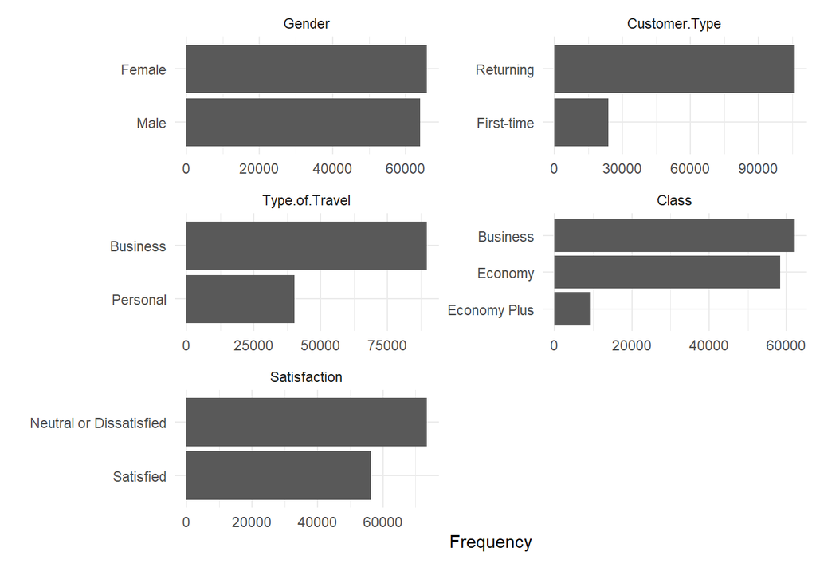

```r
plot_bar(data,ncol=2,order_bar=T,ggtheme = theme_minimal())
```

We can notice that the gender distribution is equal. The type of travel is focusing on business with most of the customer are the returning customer rather than the first time. We can notice that focus in increasing satisfaction of loyal customer will bring significant impact to the overall of airline customer satisfaction rate.

Next we will visualize the distribution in each numerical column

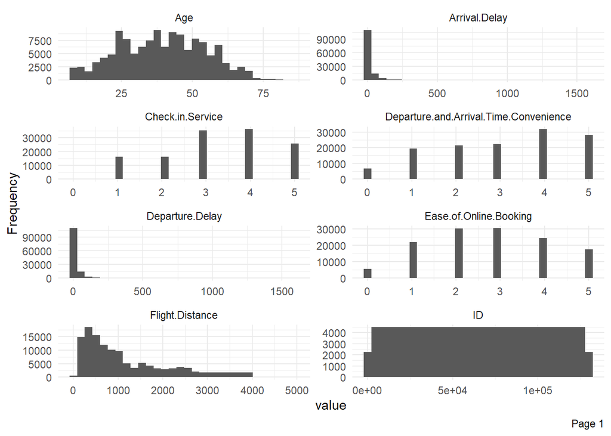

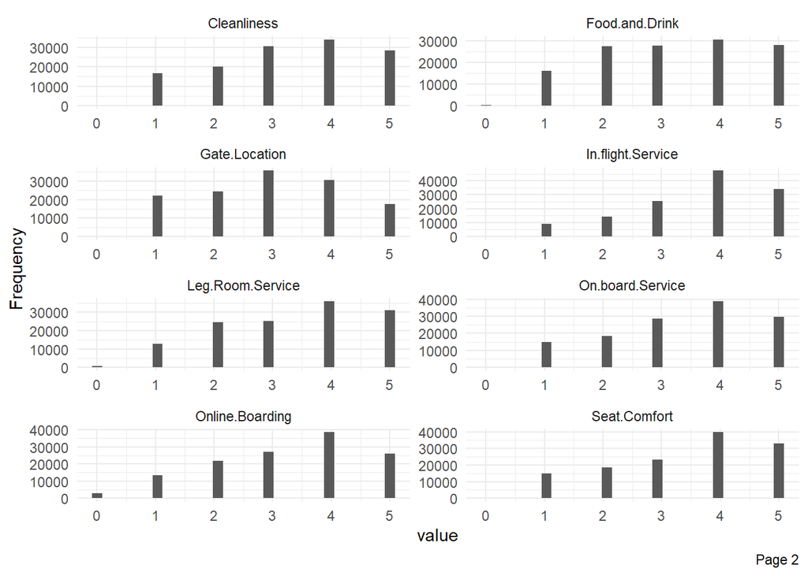

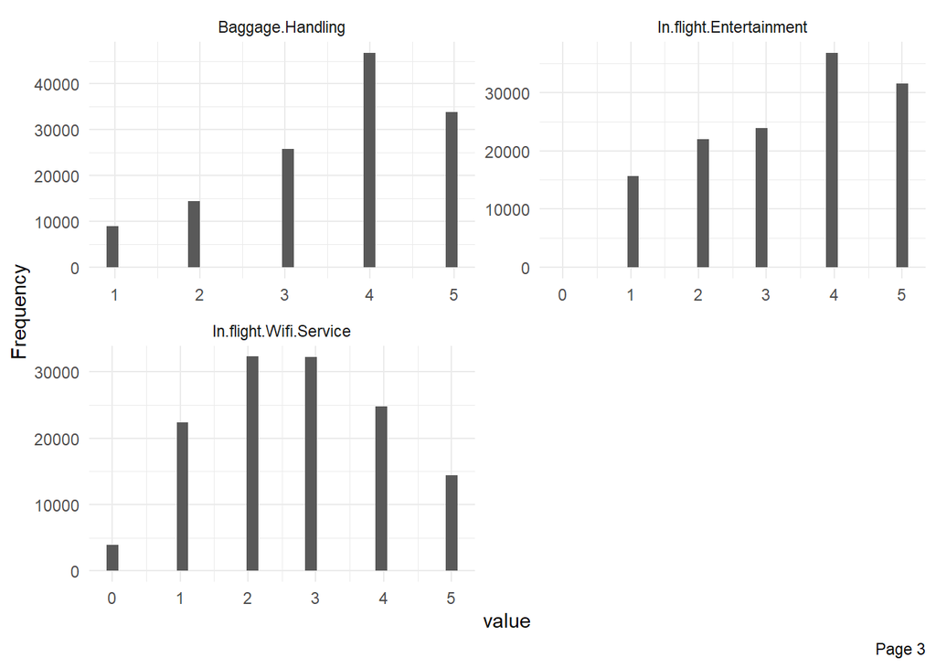

```r
plot_histogram(data, ncol=2,ggtheme = theme_minimal())
```

We notice that there is some outliers in the Arrival Delay, Departure Delay, and the Flight Distance. Let’s see in the boxplot format :

Flight Distance

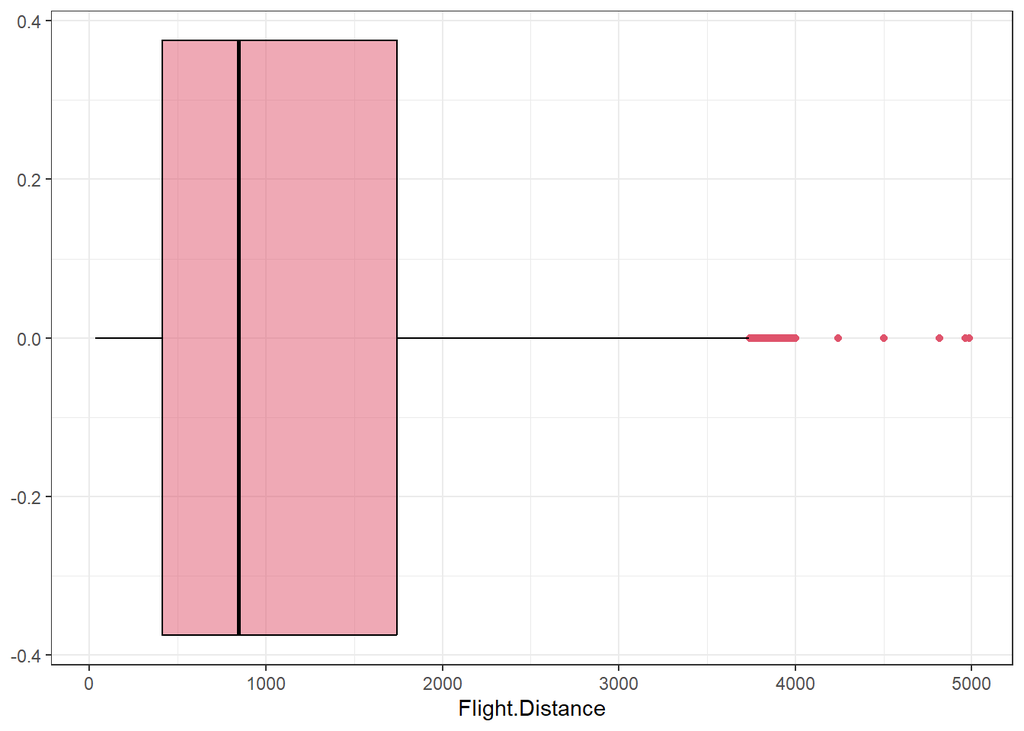

```r
ggplot(data, aes(x=Flight.Distance)) +
geom_boxplot(fill = 2,alpha = 0.5,color = 1,outlier.colour = 2) +
theme_bw()
```

Departure Delay :

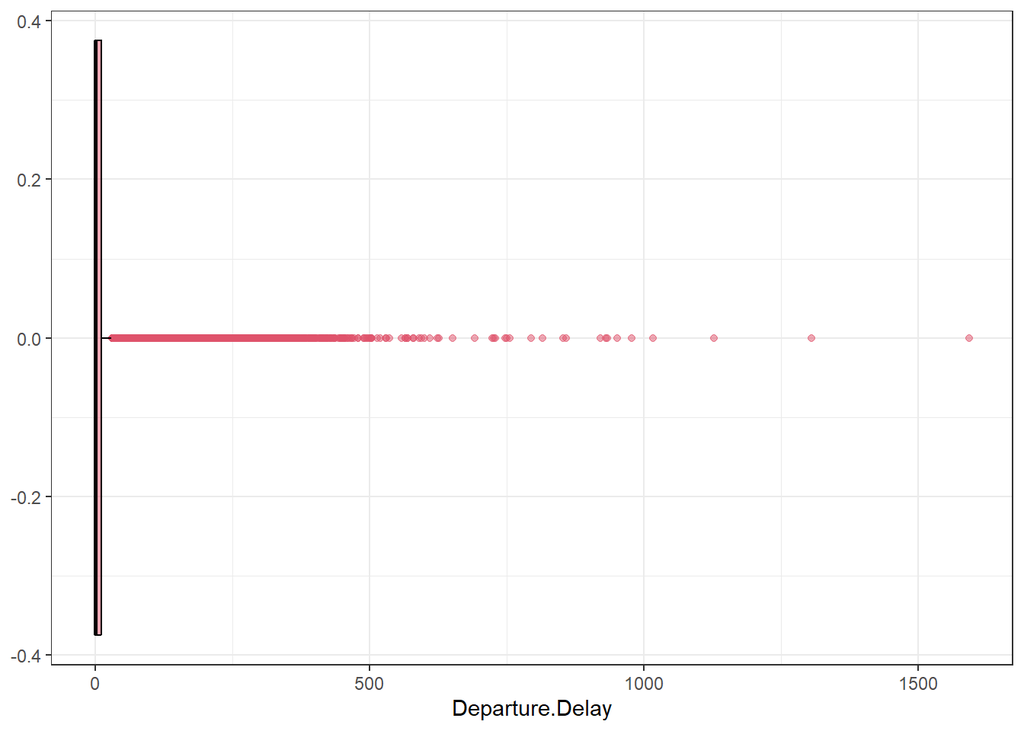

```r
ggplot(data, aes(x=Departure.Delay)) +
geom_boxplot(fill = 2,alpha = 0.5,color = 1,outlier.colour = 2) +
theme_bw()
```

Arrival Delay :

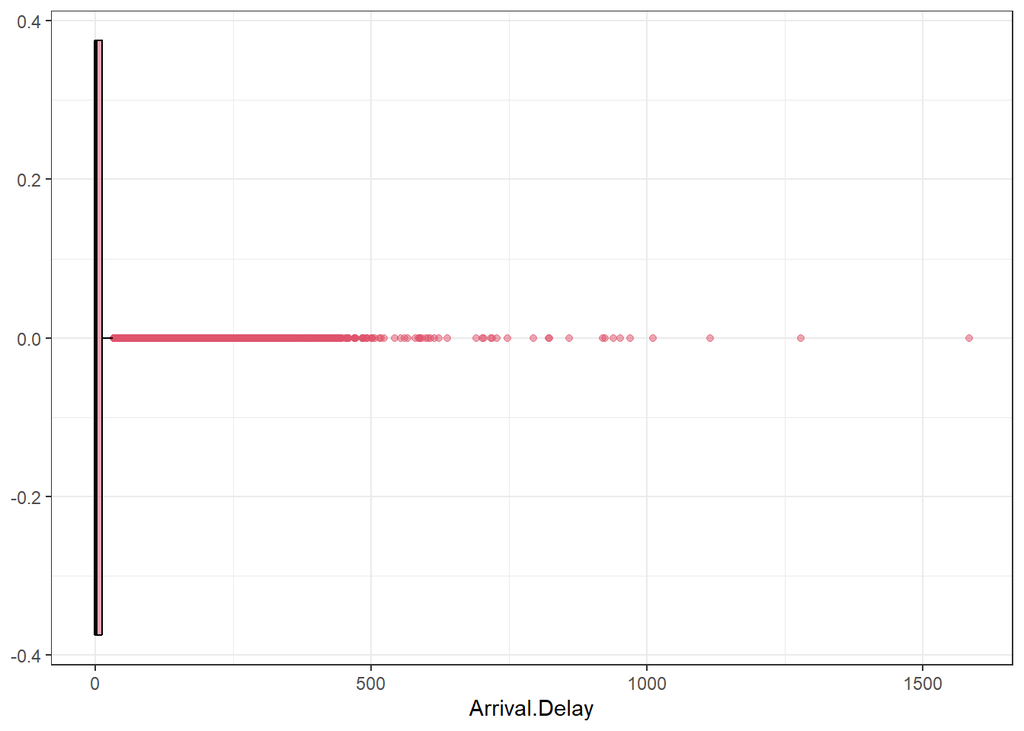

```r
ggplot(data, aes(x=Arrival.Delay)) +
geom_boxplot(fill = 2,alpha = 0.5,color = 1,outlier.colour = 2) +
theme_bw()
```

Median imputation is appropriate when the distribution of the data is skewed.

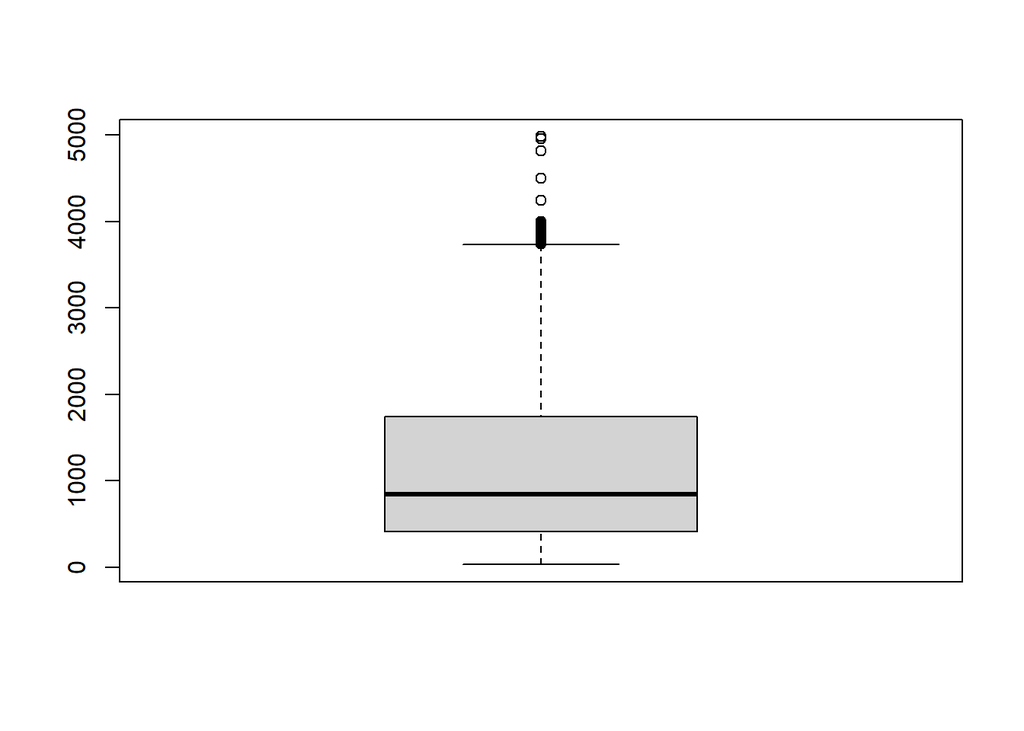

```r
data$Flight.Distance[data$Flight.Distance %in% boxplot(data$Flight.Distance)$out] = median(data$Flight.Distance)
```

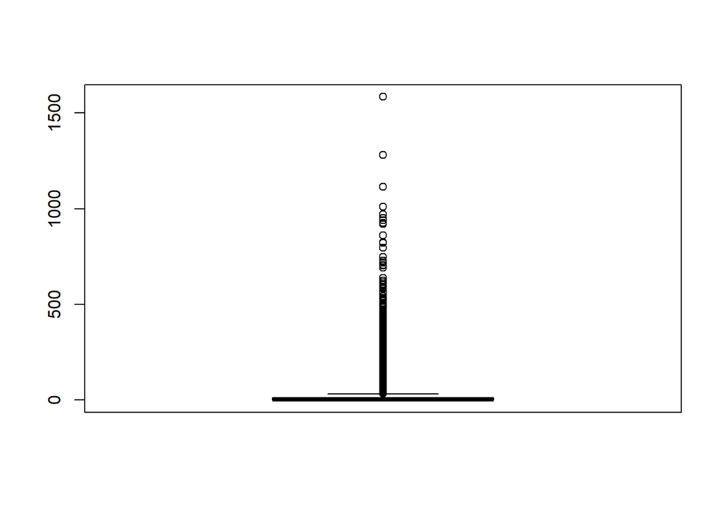

```r
data$Arrival.Delay[data$Arrival.Delay %in% boxplot(data$Arrival.Delay)$out] = median(data$Arrival.Delay)
```

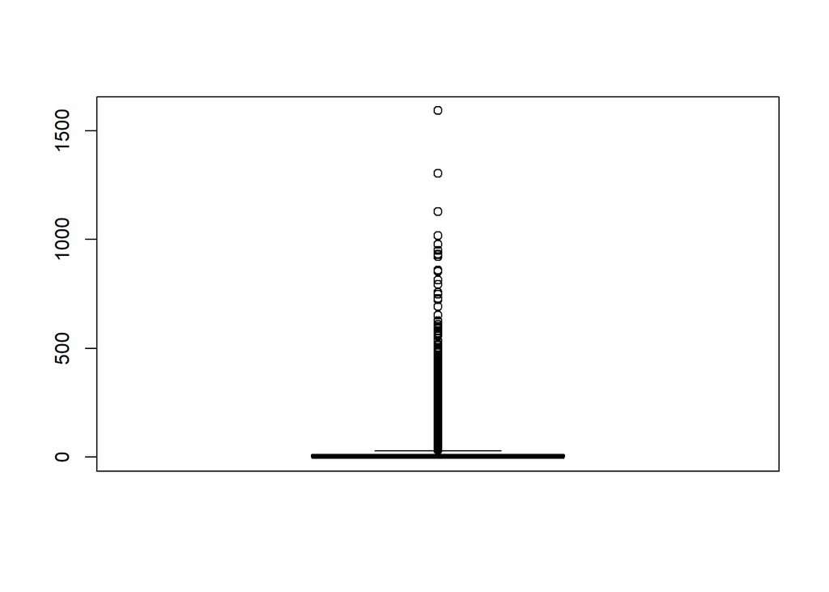

```r
data$Departure.Delay[data$Departure.Delay %in% boxplot(data$Departure.Delay)$out] = median(data$Departure.Delay)
```

## Feature Engineering

We notice that the age distribution have high variation, therefore we try to create the age_group column

```r
data = data %>% mutate(Age_Range = if_else(Age <= 16,"Children",
if_else(17 <= Age & Age <= 30,"Youth",
if_else(30 < Age & Age <= 45,"Middle Aged","Old"))))
```

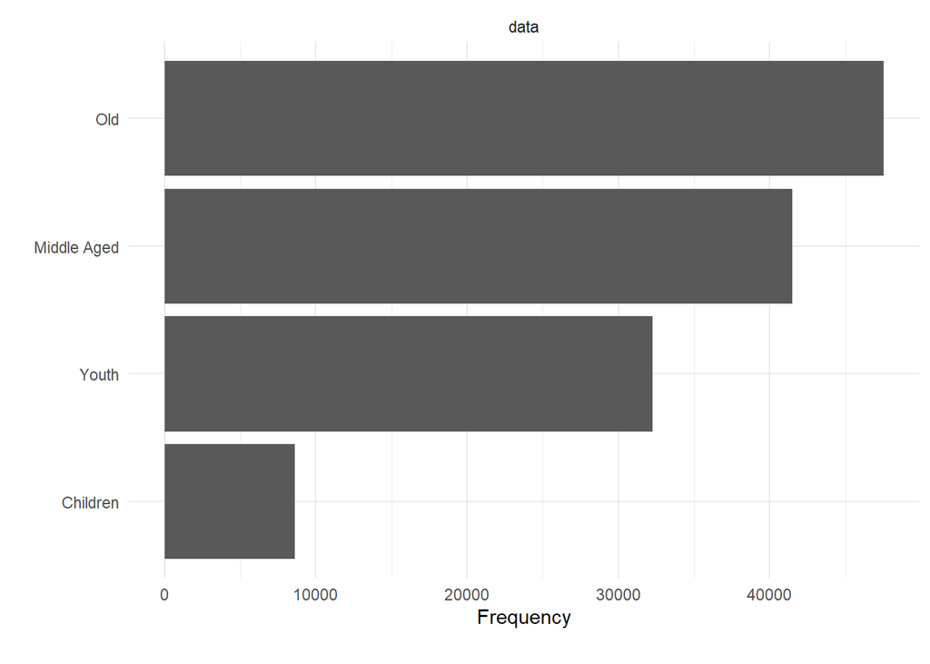

```r
plot_bar(data$Age_Range,ncol=2,order_bar=T,ggtheme = theme_minimal())
```

Now we can interpret from the age group that the largest segment of our customer is belong to old age group which is >45 years old.

Another data we can group is the flight distance which currently right skewed

```r
data = data %>% mutate(Distance_Group = if_else(Flight.Distance < 1000,"Below 1000",
if_else(1000 <= Flight.Distance & Flight.Distance <= 2000,"1000-2000",
if_else(2000 < Flight.Distance & Flight.Distance < 3000,"2000-3000",
if_else(3000 < Flight.Distance & Flight.Distance < 4000,"3000-4000","Above 4000")))))
```

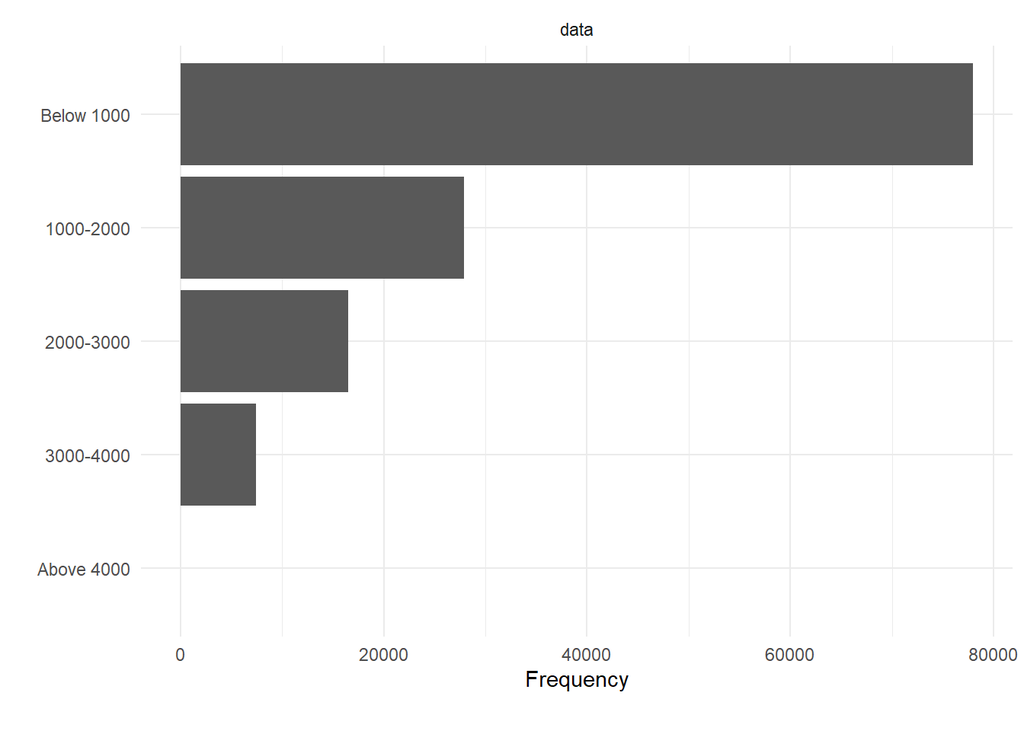

```r
plot_bar(data$Distance_Group,ncol=2,order_bar=T,ggtheme = theme_minimal())
```

## Exploratory Data Analysis

Our target is the satisfaction rate of the airlines services, therefore we need to identified how each variable are correlated to the satisfaction

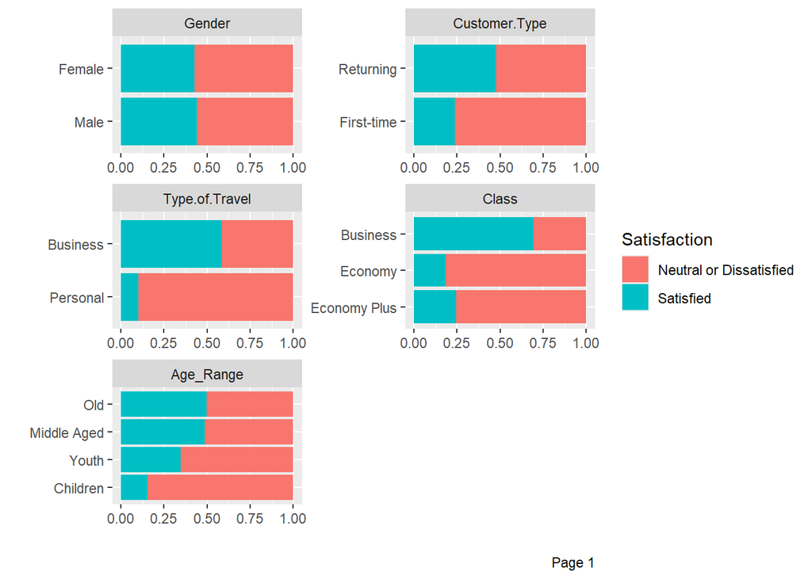

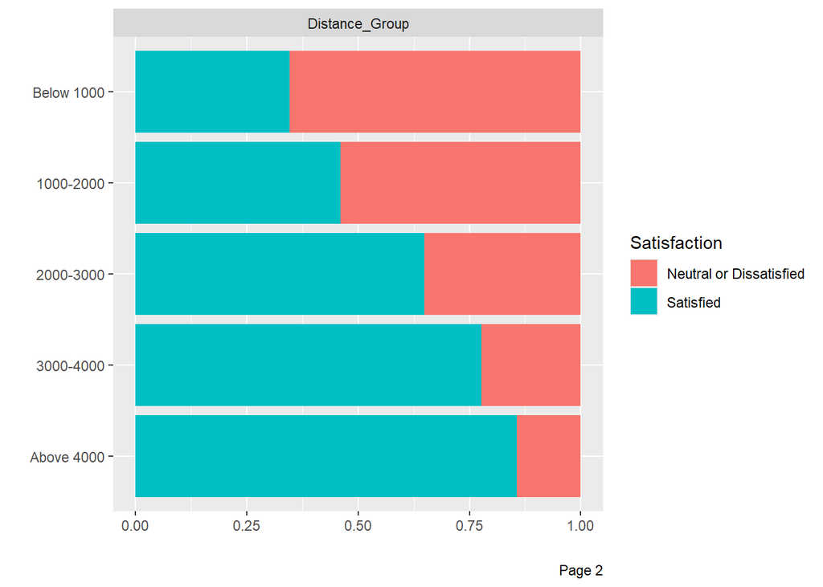

```r
plot_bar(data,by='Satisfaction',ncol=2)
```

```r
data %>% group_by(Class, Satisfaction) %>%
summarize(num=n()) %>%
mutate(percentage=round(num*100/sum(num),2))
```

```
## # A tibble: 6 × 4
## # Groups:   Class [3]
##   Class        Satisfaction              num percentage
##   <chr>        <chr>                   <int>      <dbl>
## 1 Business     Neutral or Dissatisfied 18994       30.6
## 2 Business     Satisfied               43166       69.4
## 3 Economy      Neutral or Dissatisfied 47366       81.2
## 4 Economy      Satisfied               10943       18.8
## 5 Economy Plus Neutral or Dissatisfied  7092       75.4
## 6 Economy Plus Satisfied                2319       24.6
```

We notice that economy class passenger is having high customer base but with high percentage of dissatisfied customer rate. Therefore targeting this customer base for services improvement will highly affecting airline overall satisfaction rate.

```r
data %>% group_by(Type.of.Travel, Satisfaction) %>%
summarize(num=n()) %>%
mutate(percentage=round(num*100/sum(num),2))
```

```
## # A tibble: 4 × 4
## # Groups:   Type.of.Travel [2]
##   Type.of.Travel Satisfaction              num percentage
##   <chr>          <chr>                   <int>      <dbl>
## 1 Business       Neutral or Dissatisfied 37337       41.6
## 2 Business       Satisfied               52356       58.4
## 3 Personal       Neutral or Dissatisfied 36115       89.9
## 4 Personal       Satisfied                4072       10.1
```

Personal type of travel passenger is having a third of airline total customer with the number of satisfied customer is only 10% from it. Therefore it is also important customer segment to be improved.

```r
data %>% group_by(Customer.Type, Satisfaction) %>%
summarize(num=n()) %>%
mutate(percentage=round(num*100/sum(num),2))
```

```
## # A tibble: 4 × 4
## # Groups:   Customer.Type [2]
##   Customer.Type Satisfaction              num percentage
##   <chr>         <chr>                   <int>      <dbl>
## 1 First-time    Neutral or Dissatisfied 18080       76.0
## 2 First-time    Satisfied                5700       24.0
## 3 Returning     Neutral or Dissatisfied 55372       52.2
## 4 Returning     Satisfied               50728       47.8
```

76% of first time customer are feels dissatisfied with the airline services, this could be a problem because in the long term it will reducing airlines capability in increasing customer retention.

```r
data %>% filter(Customer.Type == 'First-time') %>% group_by(Class ,Satisfaction) %>%
summarize(num=n()) %>%
mutate(percentage=round(num*100/sum(num),2))
```

```
## # A tibble: 6 × 4
## # Groups:   Class [3]
##   Class        Satisfaction              num percentage
##   <chr>        <chr>                   <int>      <dbl>
## 1 Business     Neutral or Dissatisfied  5569      60.3
## 2 Business     Satisfied                3662      39.7
## 3 Economy      Neutral or Dissatisfied 11669      85.6
## 4 Economy      Satisfied                1965      14.4
## 5 Economy Plus Neutral or Dissatisfied   842      92.0
## 6 Economy Plus Satisfied                  73       7.98
```

```r
data %>% group_by(Distance_Group) %>%
summarize(num=n()) %>%
mutate(percentage=round(num*100/sum(num),2))
```

```
## # A tibble: 5 × 3
##   Distance_Group   num percentage
##   <chr>          <int>      <dbl>
## 1 1000-2000      27924      21.5
## 2 2000-3000      16540      12.7
## 3 3000-4000       7458       5.74
## 4 Above 4000        14       0.01
## 5 Below 1000     77944      60.0
```

Based on the satisfaction rate in each of the distance group, we can notice that as the distance lower the rate of disatisfied customer is increasing. This become a problem because 60% of the airline customer is having journey below 1000.

Next we will try to analyze the service factors related to the customer satisfaction, starting with customer type :

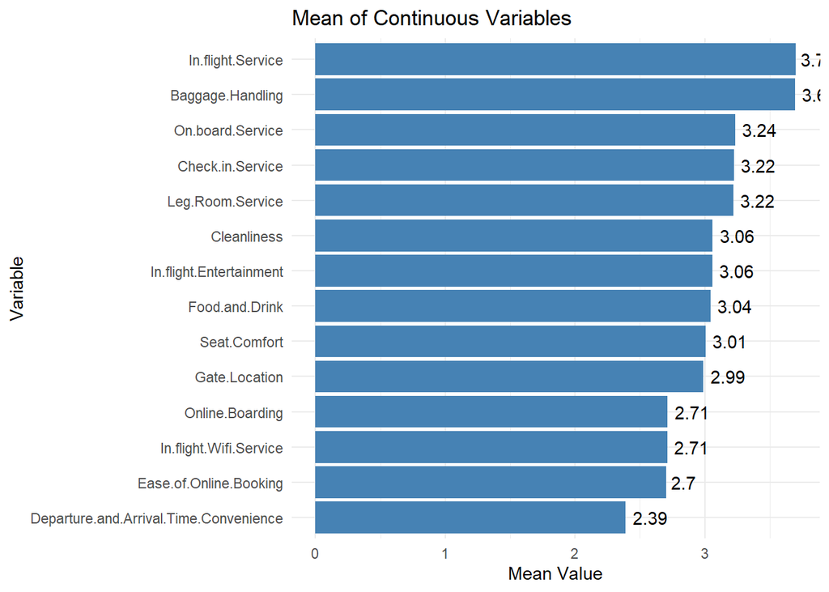

```r
# Compute mean for each continuous column
filtered_data <- data %>% filter(Customer.Type == 'First-time')
filtered_data <- subset(filtered_data, select = -c(ID, Flight.Distance, Age, Arrival.Delay, Departure.Delay))

mean_values <- sapply(filtered_data, function(x) if(is.numeric(x)) mean(x, na.rm = TRUE) else NA)
mean_values <- na.omit(mean_values)

mean_df <- data.frame(Variable = names(mean_values), Mean = mean_values)

# Remove NA values (non-numeric columns)
# Sort in descending order
mean_df <- mean_df[order(mean_df$Mean, decreasing = TRUE), ]

# Plot bar chart with highest value on top and number labels
ggplot(mean_df, aes(x = reorder(Variable, Mean), y = Mean)) +
  geom_bar(stat = "identity", fill = "steelblue") +
  geom_text(aes(label = round(Mean, 2)), hjust = -0.2) +
  coord_flip() +
  theme_minimal() +
  labs(title = "Mean of Continuous Variables", x = "Variable", y = "Mean Value")
```

We can identify that from the first time customer, the services that dissapointing them most in Departure and Arrival Time Convenience, Ease of Online Booking, and Wifi Service.

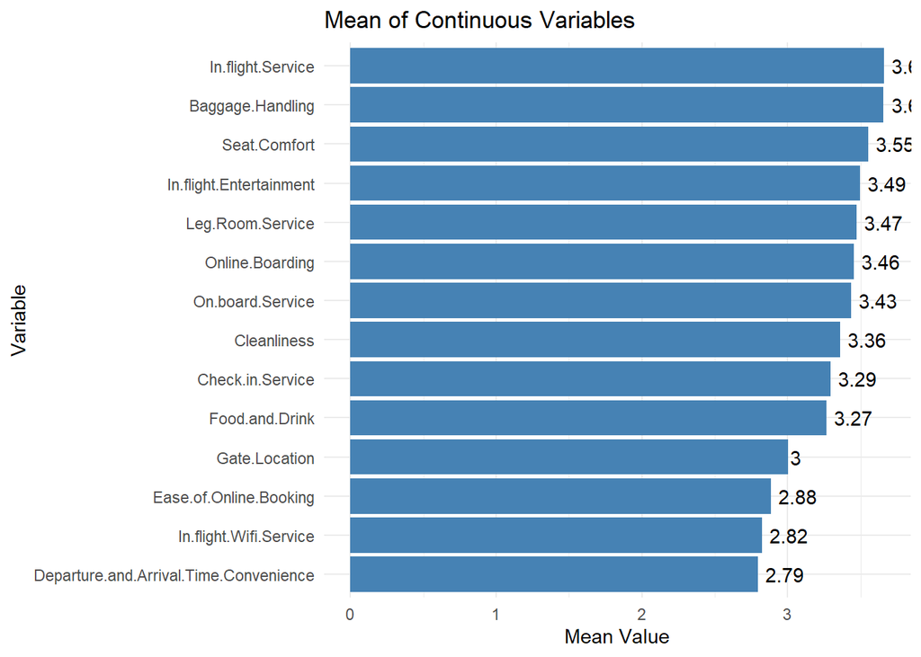

```r
# Compute mean for each continuous column
filtered_data <- data %>% filter(Type.of.Travel == 'Business')
filtered_data <- subset(filtered_data, select = -c(ID, Flight.Distance, Age, Arrival.Delay, Departure.Delay))

mean_values <- sapply(filtered_data, function(x) if(is.numeric(x)) mean(x, na.rm = TRUE) else NA)
mean_values <- na.omit(mean_values)

mean_df <- data.frame(Variable = names(mean_values), Mean = mean_values)

# Remove NA values (non-numeric columns)
# Sort in descending order
mean_df <- mean_df[order(mean_df$Mean, decreasing = TRUE), ]

# Plot bar chart with highest value on top and number labels
ggplot(mean_df, aes(x = reorder(Variable, Mean), y = Mean)) +
  geom_bar(stat = "identity", fill = "steelblue") +
  geom_text(aes(label = round(Mean, 2)), hjust = -0.2) +
  coord_flip() +
  theme_minimal() +
  labs(title = "Mean of Continuous Variables", x = "Variable", y = "Mean Value")
```

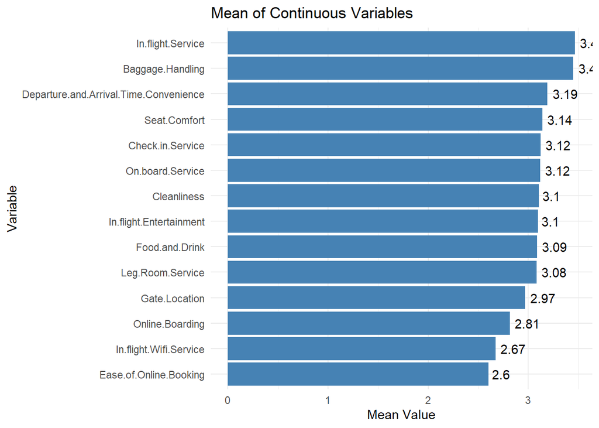

```r
# Compute mean for each continuous column
filtered_data <- data %>% filter(Class == 'Economy')
filtered_data <- subset(filtered_data, select = -c(ID, Flight.Distance, Age, Arrival.Delay, Departure.Delay))

mean_values <- sapply(filtered_data, function(x) if(is.numeric(x)) mean(x, na.rm = TRUE) else NA)
mean_values <- na.omit(mean_values)

mean_df <- data.frame(Variable = names(mean_values), Mean = mean_values)

# Remove NA values (non-numeric columns)
# Sort in descending order
mean_df <- mean_df[order(mean_df$Mean, decreasing = TRUE), ]

# Plot bar chart with highest value on top and number labels
ggplot(mean_df, aes(x = reorder(Variable, Mean), y = Mean)) +
  geom_bar(stat = "identity", fill = "steelblue") +
  geom_text(aes(label = round(Mean, 2)), hjust = -0.2) +
  coord_flip() +
  theme_minimal() +
  labs(title = "Mean of Continuous Variables", x = "Variable", y = "Mean Value")
```

We can identify that from the Economy class customers, the services that dissapointing them most in Online Boarding, Ease of Online Booking, and Wifi Service.